# W3cubDocs

/Statsmodels

# Recursive least squares

Recursive least squares is an expanding window version of ordinary least squares. In addition to availability of regression coefficients computed recursively, the recursively computed residuals the construction of statistics to investigate parameter instability.

The `RLS` class allows computation of recursive residuals and computes CUSUM and CUSUM of squares statistics. Plotting these statistics along with reference lines denoting statistically significant deviations from the null hypothesis of stable parameters allows an easy visual indication of parameter stability.

```
%matplotlib inline
import numpy as np
import pandas as pd
import statsmodels.api as sm
import matplotlib.pyplot as plt
from pandas_datareader.data import DataReader

np.set_printoptions(suppress=True)
```

## Example 1: Copper

We first consider parameter stability in the copper dataset (description below).

```
print(sm.datasets.copper.DESCRLONG)

dta = sm.datasets.copper.load_pandas().data
dta.index = pd.date_range('1951-01-01', '1975-01-01', freq='AS')
endog = dta['WORLDCONSUMPTION']

# To the regressors in the dataset, we add a column of ones for an intercept
exog = sm.add_constant(dta[['COPPERPRICE', 'INCOMEINDEX', 'ALUMPRICE', 'INVENTORYINDEX']])
```

```
This data describes the world copper market from 1951 through 1975.  In an
example, in Gill, the outcome variable (of a 2 stage estimation) is the world
consumption of copper for the 25 years.  The explanatory variables are the
world consumption of copper in 1000 metric tons, the constant dollar adjusted
price of copper, the price of a substitute, aluminum, an index of real per
capita income base 1970, an annual measure of manufacturer inventory change,
and a time trend.
```

First, construct and fir the model, and print a summary. Although the `RLS` model computes the regression parameters recursively, so there are as many estimates as there are datapoints, the summary table only presents the regression parameters estimated on the entire sample; except for small effects from initialization of the recursiions, these estimates are equivalent to OLS estimates.

```
mod = sm.RecursiveLS(endog, exog)
res = mod.fit()

print(res.summary())
```

```
                           Statespace Model Results
==============================================================================
Dep. Variable:       WORLDCONSUMPTION   No. Observations:                   25
Model:                    RecursiveLS   Log Likelihood                -153.737
Date:                Mon, 14 May 2018   AIC                            317.474
Time:                        21:45:18   BIC                            322.453
Sample:                    01-01-1951   HQIC                           318.446
                         - 01-01-1975
Covariance Type:            nonrobust
==================================================================================
                     coef    std err          z      P>|z|      [0.025      0.975]
----------------------------------------------------------------------------------
const          -6513.9922   2367.666     -2.751      0.006   -1.12e+04   -1873.452
COPPERPRICE      -13.6553     15.035     -0.908      0.364     -43.123      15.812
INCOMEINDEX     1.209e+04    762.595     15.853      0.000    1.06e+04    1.36e+04
ALUMPRICE         70.1441     32.667      2.147      0.032       6.117     134.171
INVENTORYINDEX   275.2805   2120.286      0.130      0.897   -3880.403    4430.964
===================================================================================
Ljung-Box (Q):                       14.53   Jarque-Bera (JB):                 1.91
Prob(Q):                              0.75   Prob(JB):                         0.39
Heteroskedasticity (H):               3.48   Skew:                            -0.74
Prob(H) (two-sided):                  0.12   Kurtosis:                         2.65
===================================================================================

Warnings:
[1] Parameters and covariance matrix estimates are RLS estimates conditional on the entire sample.
```

The recursive coefficients are available in the `recursive_coefficients` attribute. Alternatively, plots can generated using the `plot_recursive_coefficient` method.

```
print(res.recursive_coefficients.filtered[0])
res.plot_recursive_coefficient(range(mod.k_exog), alpha=None, figsize=(10,6));
```

```
[    2.88890056     4.94425552  1505.27013958  1856.55145415
  1597.98710024  2171.9827817   -889.38268842   122.17365406
 -4184.26788419 -6242.7260132  -7111.4525403  -6400.38238234
 -6090.45417093 -7154.9661487  -6290.92444686 -5805.25744629
 -6219.31774195 -6684.49621649 -6430.13809589 -5957.57738675
 -6407.05966649 -5983.49282153 -5224.71693423 -5286.62151094
 -6513.99218247]
```

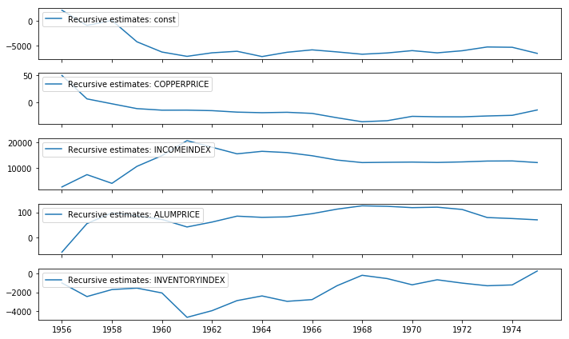

The CUSUM statistic is available in the `cusum` attribute, but usually it is more convenient to visually check for parameter stability using the `plot_cusum` method. In the plot below, the CUSUM statistic does not move outside of the 5% significance bands, so we fail to reject the null hypothesis of stable parameters at the 5% level.

```
print(res.cusum)
fig = res.plot_cusum();
```

```
[ 0.27819036  0.51898777  1.05399613  1.94931229  2.44814579  3.37264501
  3.04780124  2.47333616  2.96189072  2.58229248  1.49434496 -0.50007844
 -2.01111974 -1.75502595 -0.90603272 -1.41035323 -0.80382506  0.71254655
  1.19152452 -0.93369337]
```

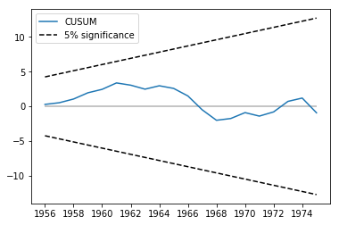

Another related statistic is the CUSUM of squares. It is available in the `cusum_squares` attribute, but it is similarly more convenient to check it visually, using the `plot_cusum_squares` method. In the plot below, the CUSUM of squares statistic does not move outside of the 5% significance bands, so we fail to reject the null hypothesis of stable parameters at the 5% level.

```
res.plot_cusum_squares();
```

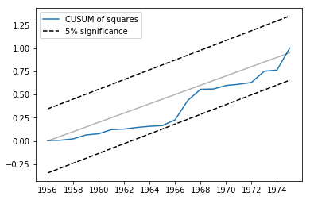

# Quantity theory of money

The quantity theory of money suggests that "a given change in the rate of change in the quantity of money induces ... an equal change in the rate of price inflation" (Lucas, 1980). Following Lucas, we examine the relationship between double-sided exponentially weighted moving averages of money growth and CPI inflation. Although Lucas found the relationship between these variables to be stable, more recently it appears that the relationship is unstable; see e.g. Sargent and Surico (2010).

```
start = '1959-12-01'
end = '2015-01-01'
m2 = DataReader('M2SL', 'fred', start=start, end=end)
cpi = DataReader('CPIAUCSL', 'fred', start=start, end=end)
```

```
def ewma(series, beta, n_window):
    nobs = len(series)
    scalar = (1 - beta) / (1 + beta)
    ma = []
    k = np.arange(n_window, 0, -1)
    weights = np.r_[beta**k, 1, beta**k[::-1]]
    for t in range(n_window, nobs - n_window):
        window = series.iloc[t - n_window:t + n_window+1].values
        ma.append(scalar * np.sum(weights * window))
    return pd.Series(ma, name=series.name, index=series.iloc[n_window:-n_window].index)

m2_ewma = ewma(np.log(m2['M2SL'].resample('QS').mean()).diff().iloc[1:], 0.95, 10*4)
cpi_ewma = ewma(np.log(cpi['CPIAUCSL'].resample('QS').mean()).diff().iloc[1:], 0.95, 10*4)
```

After constructing the moving averages using the $\beta = 0.95$ filter of Lucas (with a window of 10 years on either side), we plot each of the series below. Although they appear to move together prior for part of the sample, after 1990 they appear to diverge.

```
fig, ax = plt.subplots(figsize=(13,3))

ax.plot(m2_ewma, label='M2 Growth (EWMA)')
ax.plot(cpi_ewma, label='CPI Inflation (EWMA)')
ax.legend();
```

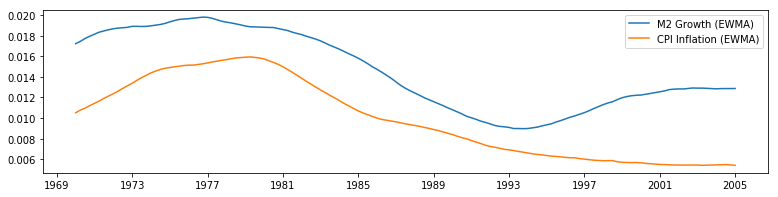

```
endog = cpi_ewma
exog = sm.add_constant(m2_ewma)
exog.columns = ['const', 'M2']

mod = sm.RecursiveLS(endog, exog)
res = mod.fit()

print(res.summary())
```

```
                           Statespace Model Results
==============================================================================
Dep. Variable:               CPIAUCSL   No. Observations:                  141
Model:                    RecursiveLS   Log Likelihood                 686.267
Date:                Mon, 14 May 2018   AIC                          -1368.535
Time:                        21:45:23   BIC                          -1362.666
Sample:                    01-01-1970   HQIC                         -1366.150
                         - 01-01-2005
Covariance Type:            nonrobust
==============================================================================
                 coef    std err          z      P>|z|      [0.025      0.975]
------------------------------------------------------------------------------
const         -0.0033      0.001     -5.935      0.000      -0.004      -0.002
M2             0.9098      0.037     24.597      0.000       0.837       0.982
===================================================================================
Ljung-Box (Q):                     1857.42   Jarque-Bera (JB):                18.30
Prob(Q):                              0.00   Prob(JB):                         0.00
Heteroskedasticity (H):               5.30   Skew:                            -0.81
Prob(H) (two-sided):                  0.00   Kurtosis:                         2.29
===================================================================================

Warnings:
[1] Parameters and covariance matrix estimates are RLS estimates conditional on the entire sample.
```

```
res.plot_recursive_coefficient(1, alpha=None);
```

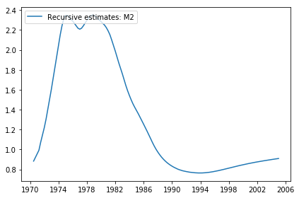

The CUSUM plot now shows subtantial deviation at the 5% level, suggesting a rejection of the null hypothesis of parameter stability.

```
res.plot_cusum();
```

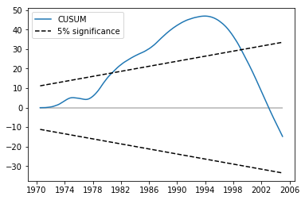

Similarly, the CUSUM of squares shows subtantial deviation at the 5% level, also suggesting a rejection of the null hypothesis of parameter stability.

```
res.plot_cusum_squares();
```

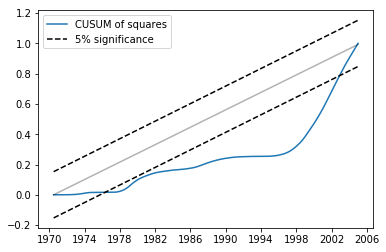

© 2009–2012 Statsmodels Developers  
© 2006–2008 Scipy Developers  
© 2006 Jonathan E. Taylor  
Licensed under the 3-clause BSD License.  
http://www.statsmodels.org/stable/examples/notebooks/generated/recursive_ls.html